# 2조 과제

### 김단비 | 김형우 | 구민지 | 유호준 | 이채림

### 문제 1: 약수와 소수 구하기

###### n이 입력값으로 주어질 때 약수의 개수를 출력하는 함수를 완성하시오.

```r
div_cnt <- function (x) {
  return(sum(x %% 1:x == 0))
}

div_cnt(6)
```

```
## [1] 4
```

###### n이 입력값으로 주어질 때 소수의 개수를 출력하는 함수를 완성하시오.

```r
prime_count <- function(x) {
  return(sum(sapply(1:x, function(x) {div_cnt(x) == 2})))
}

prime_count(4)
```

```
## [1] 2
```

### 문제 2: mtcars 데이터셋

###### mtcars 데이터셋의 구조를 확인하시오.

```r
str(mtcars)
```

```
## 'data.frame':    32 obs. of  11 variables:
##  $ mpg : num  21 21 22.8 21.4 18.7 18.1 14.3 24.4 22.8 19.2 ...
##  $ cyl : num  6 6 4 6 8 6 8 4 4 6 ...
##  $ disp: num  160 160 108 258 360 ...
##  $ hp  : num  110 110 93 110 175 105 245 62 95 123 ...
##  $ drat: num  3.9 3.9 3.85 3.08 3.15 2.76 3.21 3.69 3.92 3.92 ...
##  $ wt  : num  2.62 2.88 2.32 3.21 3.44 ...
##  $ qsec: num  16.5 17 18.6 19.4 17 ...
##  $ vs  : num  0 0 1 1 0 1 0 1 1 1 ...
##  $ am  : num  1 1 1 0 0 0 0 0 0 0 ...
##  $ gear: num  4 4 4 3 3 3 3 4 4 4 ...
##  $ carb: num  4 4 1 1 2 1 4 2 2 4 ...
```

###### mtcars 데이터셋의 요약정보를 확인하시오.

```r
summary(mtcars)
```

```
##       mpg             cyl             disp             hp
##  Min.   :10.40   Min.   :4.000   Min.   : 71.1   Min.   : 52.0
##  1st Qu.:15.43   1st Qu.:4.000   1st Qu.:120.8   1st Qu.: 96.5
##  Median :19.20   Median :6.000   Median :196.3   Median :123.0
##  Mean   :20.09   Mean   :6.188   Mean   :230.7   Mean   :146.7
##  3rd Qu.:22.80   3rd Qu.:8.000   3rd Qu.:326.0   3rd Qu.:180.0
##  Max.   :33.90   Max.   :8.000   Max.   :472.0   Max.   :335.0
##       drat             wt             qsec             vs
##  Min.   :2.760   Min.   :1.513   Min.   :14.50   Min.   :0.0000
##  1st Qu.:3.080   1st Qu.:2.581   1st Qu.:16.89   1st Qu.:0.0000
##  Median :3.695   Median :3.325   Median :17.71   Median :0.0000
##  Mean   :3.597   Mean   :3.217   Mean   :17.85   Mean   :0.4375
##  3rd Qu.:3.920   3rd Qu.:3.610   3rd Qu.:18.90   3rd Qu.:1.0000
##  Max.   :4.930   Max.   :5.424   Max.   :22.90   Max.   :1.0000
##        am              gear            carb
##  Min.   :0.0000   Min.   :3.000   Min.   :1.000
##  1st Qu.:0.0000   1st Qu.:3.000   1st Qu.:2.000
##  Median :0.0000   Median :4.000   Median :2.000
##  Mean   :0.4062   Mean   :3.688   Mean   :2.812
##  3rd Qu.:1.0000   3rd Qu.:4.000   3rd Qu.:4.000
##  Max.   :1.0000   Max.   :5.000   Max.   :8.000
```

###### gear의 개수가 4인 자동차 모델의 모든 열 정보를 추출하시오.

```r
mtcars[mtcars$gear==4,]
```

```
##                 mpg cyl  disp  hp drat    wt  qsec vs am gear carb
## Mazda RX4      21.0   6 160.0 110 3.90 2.620 16.46  0  1    4    4
## Mazda RX4 Wag  21.0   6 160.0 110 3.90 2.875 17.02  0  1    4    4
## Datsun 710     22.8   4 108.0  93 3.85 2.320 18.61  1  1    4    1
## Merc 240D      24.4   4 146.7  62 3.69 3.190 20.00  1  0    4    2
## Merc 230       22.8   4 140.8  95 3.92 3.150 22.90  1  0    4    2
## Merc 280       19.2   6 167.6 123 3.92 3.440 18.30  1  0    4    4
## Merc 280C      17.8   6 167.6 123 3.92 3.440 18.90  1  0    4    4
## Fiat 128       32.4   4  78.7  66 4.08 2.200 19.47  1  1    4    1
## Honda Civic    30.4   4  75.7  52 4.93 1.615 18.52  1  1    4    2
## Toyota Corolla 33.9   4  71.1  65 4.22 1.835 19.90  1  1    4    1
## Fiat X1-9      27.3   4  79.0  66 4.08 1.935 18.90  1  1    4    1
## Volvo 142E     21.4   4 121.0 109 4.11 2.780 18.60  1  1    4    2
```

###### gear의 개수가 4인 자동차 모델의 mpg, cyl, hp, wt 열 정보만 추출하시오.

```r
#방법1
mtcars[mtcars$gear == 4, c('mpg', 'cyl', 'hp', 'wt')]
```

```
##                 mpg cyl  hp    wt
## Mazda RX4      21.0   6 110 2.620
## Mazda RX4 Wag  21.0   6 110 2.875
## Datsun 710     22.8   4  93 2.320
## Merc 240D      24.4   4  62 3.190
## Merc 230       22.8   4  95 3.150
## Merc 280       19.2   6 123 3.440
## Merc 280C      17.8   6 123 3.440
## Fiat 128       32.4   4  66 2.200
## Honda Civic    30.4   4  52 1.615
## Toyota Corolla 33.9   4  65 1.835
## Fiat X1-9      27.3   4  66 1.935
## Volvo 142E     21.4   4 109 2.780
```

```r
#방법2
mtcars[mtcars$gear==4, c(1,2,4,6)]
```

```
##                 mpg cyl  hp    wt
## Mazda RX4      21.0   6 110 2.620
## Mazda RX4 Wag  21.0   6 110 2.875
## Datsun 710     22.8   4  93 2.320
## Merc 240D      24.4   4  62 3.190
## Merc 230       22.8   4  95 3.150
## Merc 280       19.2   6 123 3.440
## Merc 280C      17.8   6 123 3.440
## Fiat 128       32.4   4  66 2.200
## Honda Civic    30.4   4  52 1.615
## Toyota Corolla 33.9   4  65 1.835
## Fiat X1-9      27.3   4  66 1.935
## Volvo 142E     21.4   4 109 2.780
```

###### mpg가 가장 낮은 자동차 모델의 모든 열 정보를 추출하시오.

```r
mtcars[mtcars$mpg == min(mtcars$mpg),]
```

```
##                      mpg cyl disp  hp drat    wt  qsec vs am gear carb
## Cadillac Fleetwood  10.4   8  472 205 2.93 5.250 17.98  0  0    3    4
## Lincoln Continental 10.4   8  460 215 3.00 5.424 17.82  0  0    3    4
```

###### mpg가 가장 낮은 자동차 모델의 mpg, cyl, hp, wt 열 정보만 추출하시오.

```r
mtcars[mtcars$mpg == min(mtcars$mpg), c('mpg', 'cyl', 'hp', 'wt')]
```

```
##                      mpg cyl  hp    wt
## Cadillac Fleetwood  10.4   8 205 5.250
## Lincoln Continental 10.4   8 215 5.424
```

###### 연비(mpg)의 평균, 분산, 표준편차를 구하시오.

```r
mean(mtcars$mpg)
```

```
## [1] 20.09062
```

```r
var(mtcars$mpg)
```

```
## [1] 36.3241
```

```r
sd(mtcars$mpg)
```

```
## [1] 6.026948
```

###### 연비(mpg)가 중앙값(median)보다 큰 모델들의 평균, 표준편차를 구하시오.

```r
mean(mtcars$mpg > median(mtcars$mpg), na.rm = TRUE)
```

```
## [1] 0.46875
```

```r
sd(mtcars$mpg > median(mtcars$mpg), na.rm = TRUE)
```

```
## [1] 0.5070073
```

###### 연비(mpg)의 히스토그램을 그리시오.

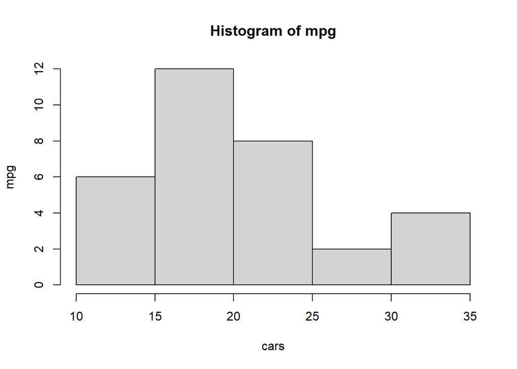

```r
hist(mtcars$mpg, main = 'Histogram of mpg', xlab = 'cars', ylab = 'mpg')
```

###### 기어(gear)의 개수에 따른 빈도수를 나타내는 barplot을 그리시오.

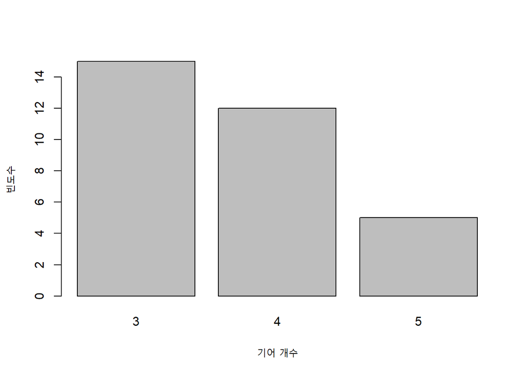

```r
barplot(table(mtcars$gear),
        xlab = '기어 개수', ylab = '빈도수')
```

###### mpg와 wt와의 관계를 나타내는 산점도(scatter plot)를 그리시오.

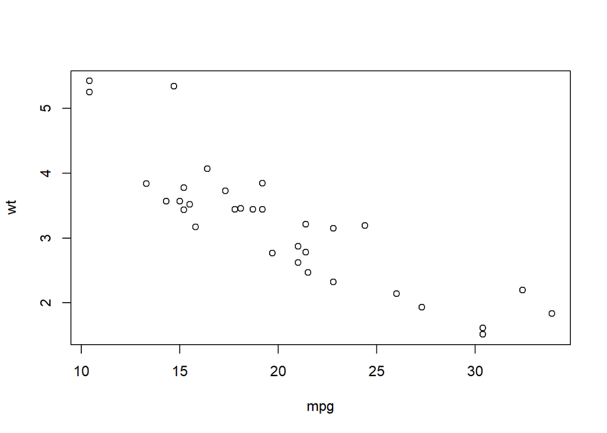

```r
plot(x = mtcars$mpg, y=mtcars$wt, xlab = "mpg", ylab="wt")
```

### 문제 3: state.x77 데이터셋

###### state.x77 데이터셋의 각 변수값에 대해 조사하시오.

```r
?state.x77
```

```
## starting httpd help server ... done
```

###### state.x77 데이터셋의 데이터 프레임을 분석하시오.

```r
st <- as.data.frame(state.x77)
st
```

```
##                Population Income Illiteracy Life Exp Murder HS Grad Frost
## Alabama              3615   3624        2.1    69.05   15.1    41.3    20
## Alaska                365   6315        1.5    69.31   11.3    66.7   152
## Arizona              2212   4530        1.8    70.55    7.8    58.1    15
## Arkansas             2110   3378        1.9    70.66   10.1    39.9    65
## California          21198   5114        1.1    71.71   10.3    62.6    20
## Colorado             2541   4884        0.7    72.06    6.8    63.9   166
## Connecticut          3100   5348        1.1    72.48    3.1    56.0   139
## Delaware              579   4809        0.9    70.06    6.2    54.6   103
## Florida              8277   4815        1.3    70.66   10.7    52.6    11
## Georgia              4931   4091        2.0    68.54   13.9    40.6    60
## Hawaii                868   4963        1.9    73.60    6.2    61.9     0
## Idaho                 813   4119        0.6    71.87    5.3    59.5   126
## Illinois            11197   5107        0.9    70.14   10.3    52.6   127
## Indiana              5313   4458        0.7    70.88    7.1    52.9   122
## Iowa                 2861   4628        0.5    72.56    2.3    59.0   140
## Kansas               2280   4669        0.6    72.58    4.5    59.9   114
## Kentucky             3387   3712        1.6    70.10   10.6    38.5    95
## Louisiana            3806   3545        2.8    68.76   13.2    42.2    12
## Maine                1058   3694        0.7    70.39    2.7    54.7   161
## Maryland             4122   5299        0.9    70.22    8.5    52.3   101
## Massachusetts        5814   4755        1.1    71.83    3.3    58.5   103
## Michigan             9111   4751        0.9    70.63   11.1    52.8   125
## Minnesota            3921   4675        0.6    72.96    2.3    57.6   160
## Mississippi          2341   3098        2.4    68.09   12.5    41.0    50
## Missouri             4767   4254        0.8    70.69    9.3    48.8   108
## Montana               746   4347        0.6    70.56    5.0    59.2   155
## Nebraska             1544   4508        0.6    72.60    2.9    59.3   139
## Nevada                590   5149        0.5    69.03   11.5    65.2   188
## New Hampshire         812   4281        0.7    71.23    3.3    57.6   174
## New Jersey           7333   5237        1.1    70.93    5.2    52.5   115
## New Mexico           1144   3601        2.2    70.32    9.7    55.2   120
## New York            18076   4903        1.4    70.55   10.9    52.7    82
## North Carolina       5441   3875        1.8    69.21   11.1    38.5    80
## North Dakota          637   5087        0.8    72.78    1.4    50.3   186
## Ohio                10735   4561        0.8    70.82    7.4    53.2   124
## Oklahoma             2715   3983        1.1    71.42    6.4    51.6    82
## Oregon               2284   4660        0.6    72.13    4.2    60.0    44
## Pennsylvania        11860   4449        1.0    70.43    6.1    50.2   126
## Rhode Island          931   4558        1.3    71.90    2.4    46.4   127
```

[output cut: 47 more lines]

```
## Oklahoma        68782
## Oregon          96184
## Pennsylvania    44966
## Rhode Island     1049
## South Carolina  30225
## South Dakota    75955
## Tennessee       41328
## Texas          262134
## Utah            82096
## Vermont          9267
## Virginia        39780
## Washington      66570
## West Virginia   24070
## Wisconsin       54464
## Wyoming         97203
```

###### state.x77 데이터셋의 각 변수별 기술적 통계량을 분석하시오.

```r
summary(st)
```

```
##    Population        Income       Illiteracy       Life Exp
##  Min.   :  365   Min.   :3098   Min.   :0.500   Min.   :67.96
##  1st Qu.: 1080   1st Qu.:3993   1st Qu.:0.625   1st Qu.:70.12
##  Median : 2838   Median :4519   Median :0.950   Median :70.67
##  Mean   : 4246   Mean   :4436   Mean   :1.170   Mean   :70.88
##  3rd Qu.: 4968   3rd Qu.:4814   3rd Qu.:1.575   3rd Qu.:71.89
##  Max.   :21198   Max.   :6315   Max.   :2.800   Max.   :73.60
##      Murder          HS Grad          Frost             Area
##  Min.   : 1.400   Min.   :37.80   Min.   :  0.00   Min.   :  1049
##  1st Qu.: 4.350   1st Qu.:48.05   1st Qu.: 66.25   1st Qu.: 36985
##  Median : 6.850   Median :53.25   Median :114.50   Median : 54277
##  Mean   : 7.378   Mean   :53.11   Mean   :104.46   Mean   : 70736
##  3rd Qu.:10.675   3rd Qu.:59.15   3rd Qu.:139.75   3rd Qu.: 81163
##  Max.   :15.100   Max.   :67.30   Max.   :188.00   Max.   :566432
```

###### state.x77 데이터셋의 각 변수별 확률분포를 시각화하시오.

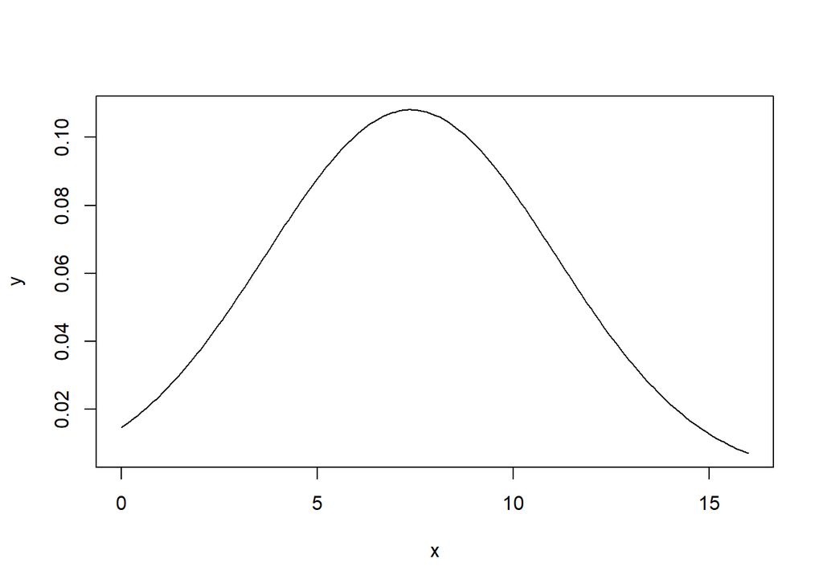

```r
x <- seq(0, 16, length=200)
y <- dnorm(x, mean(st$Murder), sd(st$Murder))
plot(x,y, type = 'l')
```

###### state.x77 데이터셋의 각 변수간의 관계에 대해 분석하고 시각화하시오.

```r
# 시각화 : 파랄수록 높은 상관관계, 빨갈수록 낮은 상관관계
install.packages('corrplot',
                 repos = "http://cran.us.r-project.org")
```

```
##
##  C:\Users\USER\AppData\Local\Temp\RtmpGclAxl\downloaded_packages
```

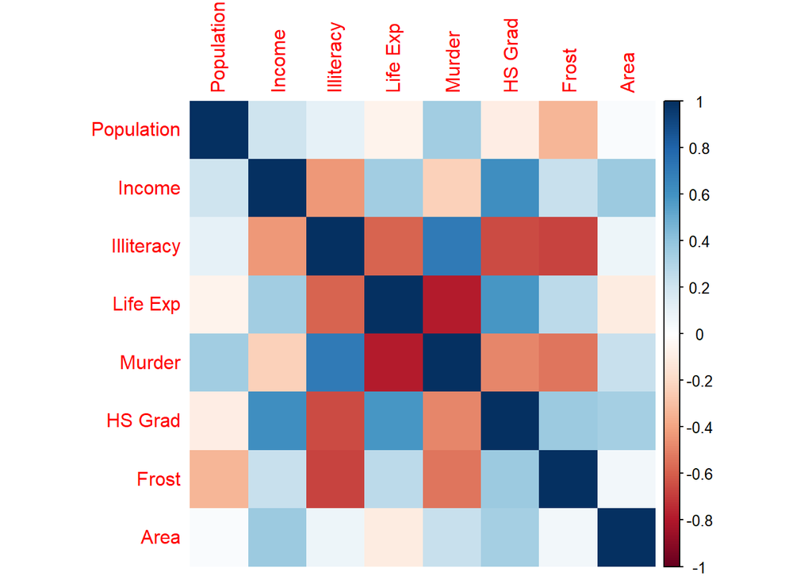

```r
library(corrplot)
mcor <- cor(st, method="pearson")
corrplot(mcor, method = 'shade', shade.col = NA, t1.col='black', t1.srt=45)
```

###### state.x77 데이터셋을 대상으로 통계적 분석을 실행하고 통계적 분석을 통해 얻은 분석 결과를 기술하시오.

```r
#Murder와 Life Exp는 반비례 관계(-0.78)
#Murder와 Illiteracy는 정비례 관계(0.70)
```